# Data607 - Project 2: Data Transformation with Astronomical Data

## Sloan Digital Sky Survey Data

### Tidying the Dataset

Similar to with the gaia datasets we will tidy the Sloan Digital Sky survey data into tidy format.

```r
id_columns <- c("pl_name", "hostname", "discoverymethod", "disc_year", "soltype", "pl_controv_flag", "disc_facility")

sdsdf_filtered <- sdsdf %>%
  select(all_of(id_columns), starts_with("sy_"))

sdsdf_tidy <- sdsdf_filtered %>%
  pivot_longer(
    cols = starts_with("sy_"),
    names_to = c("type", ".value"),
    names_sep = "_",
    values_drop_na = TRUE
  )

sdsdf_tidy <- sdsdf_tidy %>%
  filter(!is.na(vmag) & !is.na(kmag) & !is.na(gaiamag))
```

### Analysis of the Sloan Digital Sky Survey Dataset

We will begin analyzing the dataset with the following code blocks:

```r
sdsdf_tidy %>%
  group_by(type) %>%
  summarise(
    mean_vmag = mean(vmag, na.rm = TRUE),
    median_vmag = median(vmag, na.rm = TRUE),
    sd_vmag = sd(vmag, na.rm = TRUE),
    mean_kmag = mean(kmag, na.rm = TRUE),
    median_kmag = median(kmag, na.rm = TRUE),
    sd_kmag = sd(kmag, na.rm = TRUE),
    mean_gaiamag = mean(gaiamag, na.rm = TRUE),
    median_gaiamag = median(gaiamag, na.rm = TRUE),
    sd_gaiamag = sd(gaiamag, na.rm = TRUE)
  ) %>%
  mutate(
    percent_mean_vmag = mean_vmag / sum(mean_vmag, na.rm = TRUE) * 100,
    percent_mean_kmag = mean_kmag / sum(mean_kmag, na.rm = TRUE) * 100,
    percent_mean_gaiamag = mean_gaiamag / sum(mean_gaiamag, na.rm = TRUE) * 100
  )
```

```
## # A tibble: 1 × 13
##   type  mean_vmag median_vmag sd_vmag mean_kmag median_kmag sd_kmag mean_gaiamag
##   <chr>     <dbl>       <dbl>   <dbl>     <dbl>       <dbl>   <dbl>        <dbl>
## 1 sy         13.6        14.2    2.39      11.6        12.3    2.31         13.4
## # ℹ 5 more variables: median_gaiamag <dbl>, sd_gaiamag <dbl>,
## #   percent_mean_vmag <dbl>, percent_mean_kmag <dbl>,
## #   percent_mean_gaiamag <dbl>
```

```r
sdsdf_tidy %>%
  count(type) %>%
  mutate(percent = n / sum(n) * 100)
```

```
## # A tibble: 1 × 3
##   type      n percent
##   <chr> <int>   <dbl>
## 1 sy    35356     100
```

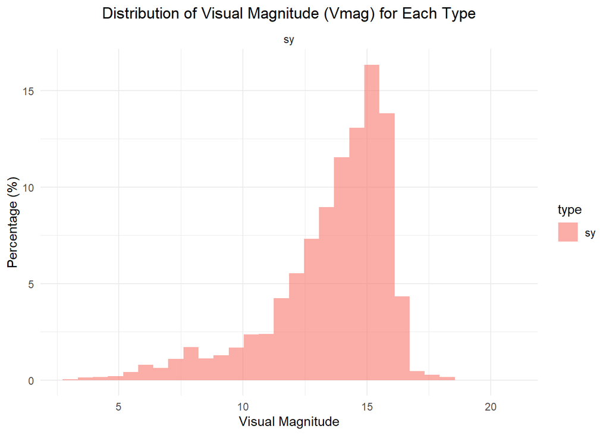

```r
ggplot(sdsdf_tidy, aes(x = vmag, fill = type)) +
  geom_histogram(aes(y = ..count.. / sum(..count..) * 100), bins = 30, alpha = 0.6) +
  facet_wrap(~ type) +
  theme_minimal() +
  labs(title = "Distribution of Visual Magnitude (Vmag) for Each Type", x = "Visual Magnitude", y = "Percentage (%)") +
  theme(
    plot.title = element_text(hjust = 0.5)
  )
```

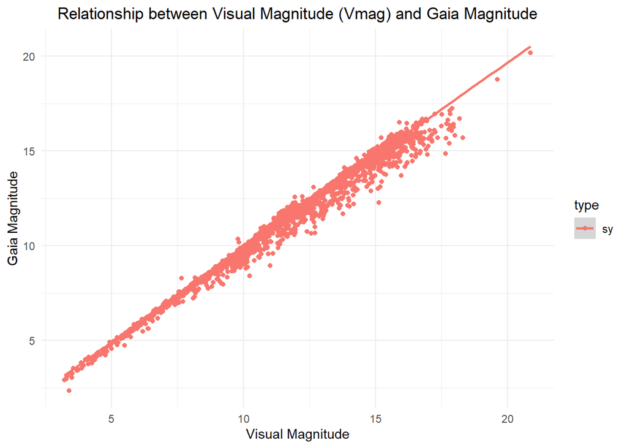

```r
ggplot(sdsdf_tidy, aes(x = vmag, y = gaiamag, color = type)) +
  geom_point() +
  geom_smooth(method = "lm") +
  theme_minimal() +
  labs(title = "Relationship between Visual Magnitude (Vmag) and Gaia Magnitude", x = "Visual Magnitude", y = "Gaia Magnitude") +
  theme(
    plot.title = element_text(hjust = 0.5)
  )
```

**Findings:** From this relationship between the visual magnitude and the gaia magnitude, there is a high correlation between the `Vmag` and `Gaia Magnitude, where as the visual magnitude increases, the gaia magnitude also increases. Thus objects that are brighter in the visible spectrum tend to be brighter in the Gaia band.

```r
sdsdf_tidy %>%
  group_by(discoverymethod) %>%
  summarise(
    n = n(),  # Count of observations
    mean_vmag = mean(vmag, na.rm = TRUE),
    sd_vmag = sd(vmag, na.rm = TRUE),
    mean_kmag = mean(kmag, na.rm = TRUE),
    sd_kmag = sd(kmag, na.rm = TRUE)
  ) %>%
  mutate(
    percent_n = n / sum(n) * 100,  # Percentage of total count
    percent_mean_vmag = mean_vmag / sum(mean_vmag) * 100,
    percent_mean_kmag = mean_kmag / sum(mean_kmag) * 100
  ) %>%
  select(discoverymethod, n, percent_n, mean_vmag, percent_mean_vmag, mean_kmag, percent_mean_kmag)
```

```
## # A tibble: 10 × 7
##    discoverymethod             n percent_n mean_vmag percent_mean_vmag mean_kmag
##    <chr>                   <int>     <dbl>     <dbl>             <dbl>     <dbl>
##  1 Astrometry                  2   0.00566     10.2               7.99      6.25
##  2 Disk Kinematics             1   0.00283      8.44              6.65      5.94
##  3 Eclipse Timing Variati…    21   0.0594      14.6              11.5      13.7
##  4 Imaging                   117   0.331        9.13              7.19      6.90
##  5 Orbital Brightness Mod…    21   0.0594      13.9              11.0      13.0
##  6 Pulsar Timing               1   0.00283     20.9              16.4      15.6
##  7 Pulsation Timing Varia…     2   0.00566     14.0              11.0      13.7
##  8 Radial Velocity          2519   7.12         7.88              6.20      5.69
##  9 Transit                 32534  92.0         14.0              11.1      12.0
## 10 Transit Timing Variati…   138   0.390       14.0              11.0      12.1
## # ℹ 1 more variable: percent_mean_kmag <dbl>
```

**Findings:** From this analysis, this shows that the transit method is really dominant as it shows a large percentage of observations for detecting exoplanets where the percentage is `92.02%`. This is definitely expected since the transit method is one of the most effective techniques for detecting exoplanets when monitoring large numbers of stars. Pulsar Timing and Eclipse timing variations have high mean magnitudes, which indicates they are typically used to detect vary faint objects that are harder to observe. The imaging and radial velocity methods show relatively low mean magnitudes, which indicates that they are used to detect brighter objects.

Lastly, I will make a time series of the discoveries over time for the exoplanets.

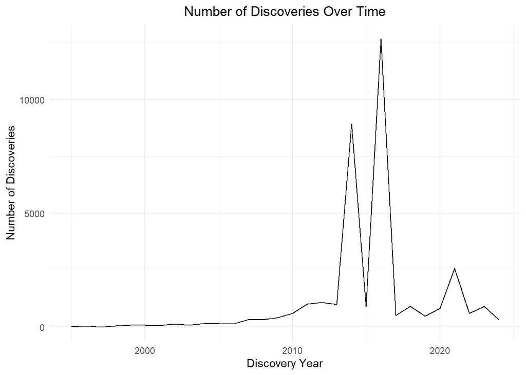

```r
sdsdf_tidy %>%
  group_by(disc_year) %>%
  summarise(count = n()) %>%
  ggplot(aes(x = disc_year, y = count)) +
  geom_line() +
  theme_minimal() +
  labs(title = "Number of Discoveries Over Time", x = "Discovery Year", y = "Number of Discoveries") +
  theme(
    plot.title = element_text(hjust = 0.5)
  )
```

This graph explains how prior to the 2000s there were very few discoveries before the year 2000, with the number of detections remaining low. From 2000 to 2010, there was an increase in the number of discoveries which were indications that there were improvements in detection technology and techniques in radial velocity and transit methods explained in [Gaia’s website](https://sci.esa.int/web/exoplanets/-/60649-exoplanet-mission-timeline) and [NASA’s interactive timeline](https://exoplanets.nasa.gov/alien-worlds/historic-timeline/). From 2010 to 2016, this had a large number of discoveries stemming from the large-scale survey missions from [NASA’s Kepler Space Telescope](https://exoplanets.nasa.gov/alien-worlds/kepler-timeline/) which uses the transit method. There weas a decline after 2016, which may be from fewer missions, but an increase around 2018 where the launch of TESS was used to analyze exoplanets. COVID also may have been an impact on this time series as well, since this impacted numerous research projects. Overall, this should increase with the launch of [JWST](https://science.nasa.gov/mission/webb/) (James Webb Space Telescope) and PLATO (Planetary Transits and Oscillations of Stars) from [ESA](https://sci.esa.int/web/plato/) when it launches in 2025.

### Exporting this file to CSV

This exports the file into csv for reproductibility.

```r
write.csv(sdsdf_tidy, "sdsdf_tidy.csv", row.names = FALSE)
```

## Conclusion

With the analysis of the Gaia Datasets, it appears there may need to be further analysis on the anomalies where we may need to classify the stars by distances with respect to the parallax values. This will determine whether the brighter stars (lower magnitude) with high parallax values are part of known nearby stellar systems. We may need to examine unique stars with high parallax and high magnitude to determine whether or not these can be unique stars or errors. Lastly for the gaia datasets, with the concentration of stars at low parallax values may indicate the detection limit of Gaia’s parallax measurements, where stars below a certain parallax threshold are difficult to measure accurately. To continue to investigate the outliers for proper motion with the Gaia datasets, we can analyze the high proper motion stars to check if they are using their parallax values and if they are close it may explain why their motion is rapid across the sky. Similar to the Gaia Datasets, with the Sloan Digital Sky surveys, further analysis may be needed to analyze the outliers to determine if there are any errors and to determine if any of the detections can be false positives which is common in exoplanet detections.